# Have Middelkoop’s predictions come true?

In 2001 Middelkoop et al. conducted groundbreaking research into the outflow patterns of the Rhine river in Europe. Their models indicated that rising temperatures were leading to a rise in winter discharge due to increased snow-melt, and a decrease in summer discharge due to lower levels of winter snow storage and increase of evapotranspiration in the warmer months.

Their results were published in the scientific journal *Climatic Change* and influenced policy makers, as well as hydrological projections for the next two decades.

The full research paper [*Impact of Climate Change on Hydrological Regimes and Water Resources Management in the Rhine Basin*](https://www.researchgate.net/publication/200043966_Impact_of_Climate_Change_on_Hydrological_Regimes_and_Water_Resources_Management_in_the_Rhine_Basin) is available online.

Now that twenty years have passed, we are going to dive in to the data and examine whether their predictions have come true.

### Where are we?

First, let’s have a look at the area we will be covering, and at the geographic distribution of the gauging stations from where we are collecting the data.

[interactive chart not shown]

We can also take a closer look at the stations in this interactive map and learn more about each one, most relevantly the altitude, area and runoff class.

One imporant thing to point out is that along the river there is a lot of variation in terms of topography. The beginning of the catchment is in the Alpine and pre-Alpine areas where the highest and largest differences in altitude are (range of 300m - 1200m). These areas’ runoff is most influenced by snow.  
The river then runs through the German Middle Mountain area with altitudes between 150m and 700m, through the scenic Mosel basin, before reaching the lowlands of the Vecht catchment. There are minimal differences in elevantion in this stage, and it is where groundwater plays its biggest role for water balance of the catchment.

The stations can therefore be subdivided into three groups - upstream, midstream and downstream. The plot below shows us the average runoff per station, within their flow categories.

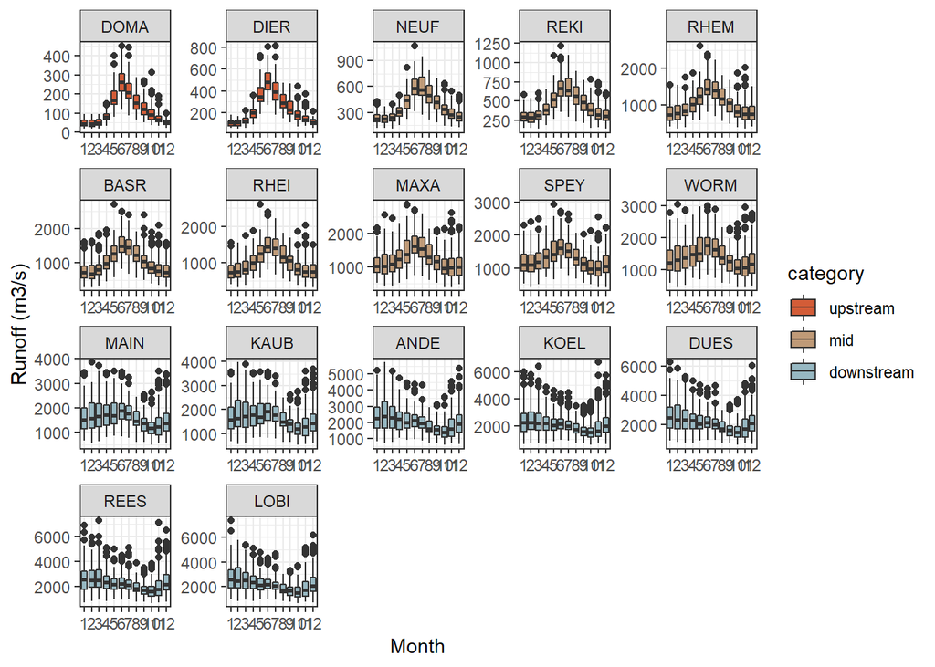

We can notice that while the runoff figures for the very first stations in red are in the low hundreds, the very last figures are much higher in the thousands.

This is because the catchment area represents the total area from which precipitation is being collected into the river flow. At the very beginning of the river, at the highest altitudes, the catchment area is small. However by the very last stations, where altitude has decreased, the runoff is at its highest due to the entirety of the river’s catchment area being behind the station, collecting runoff to be taken to the North Sea basin.

To avoid having overwhelmingly large graphs with too much detail, we will be focusing on only three stations moving forward. These are DOMA (Doma/Esr), BASR (Basel, Reinhalle) and KOEL (Koeln), which are each respectively representative of the upstream, mid and downstream categories.

### What does the historical data tell us about average seasonal runoff?

We will take a closer look through regression analysis. We will use two different regression models, loess and linear, to showcase the trends through two difference lenses. On the one hand, through the loess model (blue line) we will see in more detail the variations in runoff through time. Our linear model (orange line) creates a general trend line which disregards outliers and highlights the encompassing trends.

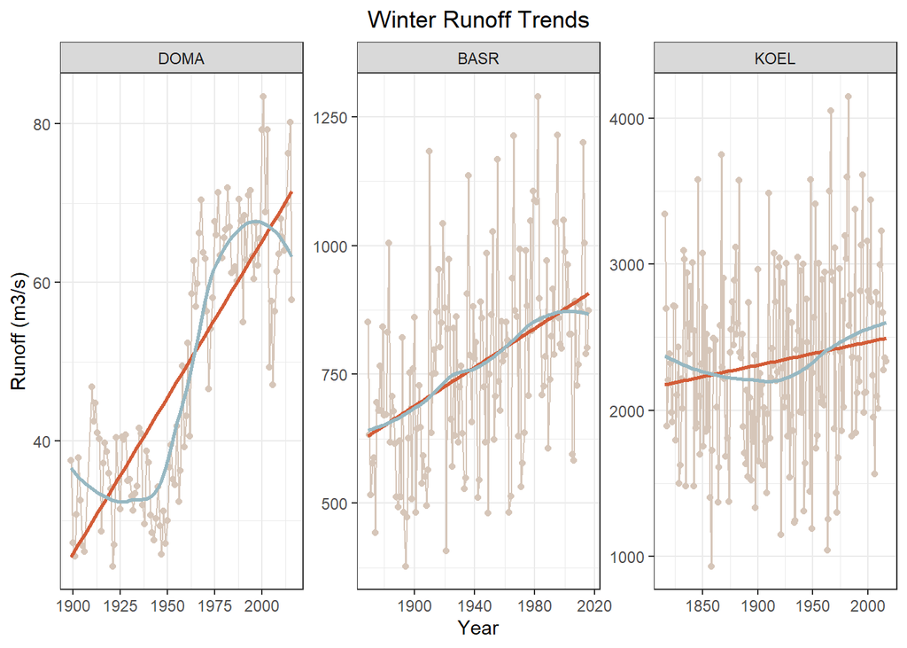

Further dowmnstream the effects are weakened as these stations are less dependent on snowmelt.

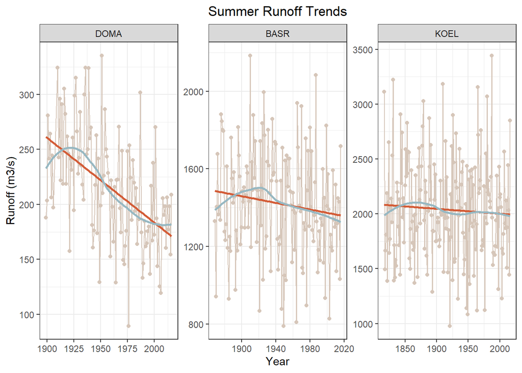

Their results also showed that the Alps had the biggest change in summer runoff, with the biggest decrease. This is consistent with our findings above, which show just that in the DOMA catchment. Further downstream the effects are less extreme in the summer.

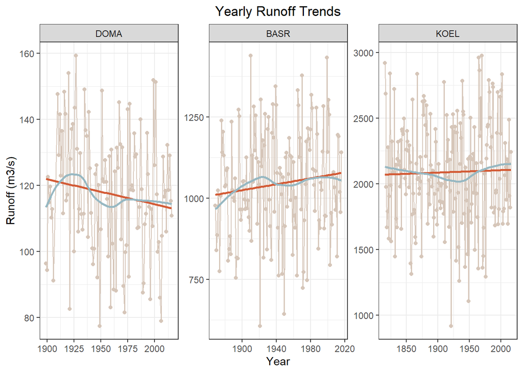

Our yearly data showcases that the most drastic change in flow is in the Alpine regions, as our seasonal models indicated. While upstream the Rhine is experiencing an overall decrease in flow due to the above mentioned factors, the mid and downstream regions are experiencing an increase due to increased percipitation. Middelkoop notes in their results that the yearly differences between summer and winter runoff are decreasing, and even inverting, in the Alps, while the downstream regions are experiencing amplified changes. Our results above indicate that on the whole, the downstrem catchments are experiencing the least drastic change over time. This might also be due to the availability of groundwater which is not affected by evapotranspiration in the summer.

We can see above that the summer runoff values are decreasing, while the winter ones are increasing.

### Conclusion

In this summary we simplified the records by focusing on representative stations. Middelkoop notes that there are variations in daily runoff among individual gauging stations, particularly in the Alpine regions. However, even with only selected stations’ data we can see that a lot of the indicators match the findings of Middelkoop et al.

The increase in temperature indicates decreased storage in the form of winter snow and ice, and in turn an increase in winter percipitation. This in turn leads to an increase in winter runoff, especially in the Alps, but also a decrease in the summer due to fewer depositories. We have already come across the issues that come with these changes in water flow, such as staggeringly low levels in the summer of [2018](https://www.dw.com/en/germany-swelters-under-heat-wave/a-44839919) and [2019](https://rivercruisepassenger.com.au/heatwave-and-low-water-levels-in-europe-may-force-river-cruise-itinerary-changes/), and flooding in the winter of [2020](https://www.general-anzeiger-bonn.de/ga-english/news/rhine-level-in-bonn-is-currently-rising-rapidly_aid-48739343).

The implications of these changes in water flow are far reaching and severe, with the potential to impact ecology, freshwater availability, commerce, industry and agriculture across several societies.

Looking at the data one could conclude that Middelkoop et al.’s predictions have been proven to be reasonably accurate. The runoff in the winter months has had an upward trend, while the summer months have been experiencing a decrease in runoff. The data supports the hypothesis that rising average temperatures have this effect on the river’s discharge, which has important implications for the socities that depend on it as a source of fresh water, as well as economical, agricultural and industry implications.